# PubH 6886 Fall 2025 Assignment One

## Part Two

5. (14 pts.) Use $K$-means clustering with squared Euclidean distance to cluster the observations based on the 30 features corresponding to mean, se, and worst (scale them to each have variance 1). Consider $K$ = 2 to 10 cluster solutions and select the best solution based on a plot of the total within cluster sum of squares vs. the number of clusters. Use 100 random starts and set the seed to 1 (`set.seed(1)`) prior to running the code for obtaining all 9 clusterings.

Based on the graph, the best amount of clusters to consider it $K = 3$, as that is about when the graph has a “strong” elbow.

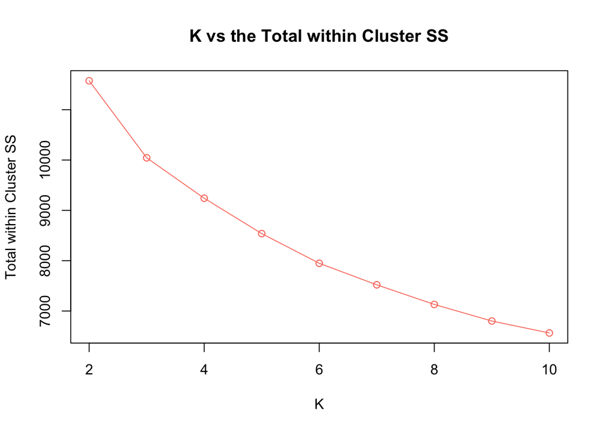

```r
set.seed(1) # sets the seed
scaledBdiag <- scale(lesserBdiag)# scales the data
# K-means clustering for K = 2 through K = 10
km_k2 <- kmeans(x = scaledBdiag, centers = 2, nstart = 100)
km_k3 <- kmeans(x = scaledBdiag, centers = 3, nstart = 100)
km_k4 <- kmeans(x = scaledBdiag, centers = 4, nstart = 100)
km_k5 <- kmeans(x = scaledBdiag, centers = 5, nstart = 100)
km_k6 <- kmeans(x = scaledBdiag, centers = 6, nstart = 100)
km_k7 <- kmeans(x = scaledBdiag, centers = 7, nstart = 100)
km_k8 <- kmeans(x = scaledBdiag, centers = 8, nstart = 100)
km_k9 <- kmeans(x = scaledBdiag, centers = 9, nstart = 100)
km_k10 <- kmeans(x = scaledBdiag, centers = 10, nstart = 100)

tot_withinVec <- c(km_k2$tot.withinss, km_k3$tot.withinss, km_k4$tot.withinss,
                   km_k5$tot.withinss, km_k6$tot.withinss, km_k7$tot.withinss,
                   km_k8$tot.withinss, km_k9$tot.withinss, km_k10$tot.withinss)
plot(2:10, tot_withinVec, col = "salmon",
     main = "K vs the Total within Cluster SS",
     xlab = "K", ylab = "Total within Cluster SS", type = "o")
points(2:10, tot_withinVec, col = "salmon")
```

6. (3 pts.) Does the 2-cluster solution from part (e) correspond to the `diagnosis` (`M` = malignant, `B` = benign)? Justify your response.

Yes, the 2-cluster solution corresponds to the `diagnosis`. The outcome being predicted, `diagnosis`, by the response variables is dichotomous and the two clusters represent the two options. Like the in-class example, the 3-cluster best performed better than the other k-clusters when the outcome was multinominal with 3 levels. The 2-cluster solution sorted around $91.04\%$ of the outcomes into the correct bin, so to speak, so it seems to be a good model.

```r
# finds the proportion correctly predicted
mean(km_k2$cluster == diagMat$diagF)
```

```
[1] 0.9103691
```

7. (8 pts.) Use agglomerative clustering based on Euclidean distance with complete linkage to cluster the observations based on the 30 features corresponding to mean, se, and worst (scale them to each have variance 1). Does the 2-cluster solution correspond to the `diagnosis` (`M` = malignant, `B` = benign)? Justify your response.

Yes, the 2-cluster solution corresponds to the `diagnosis`. The outcome being predicted, `diagnosis`, by the response variables is dichotomous and the two clusters represent the two options. The 2-cluster solution sorted around $63.09\%$ of the outcomes into the correct bin, so to speak. This doesn’t seem to be as good of a predictive model as the K-means clustering model.

```r
# agglomerative cluster
bdiag_complete <- hclust(dist(scaledBdiag), method = "complete")
# finds the proportion correctly predicted
mean(cutree(bdiag_complete, k = 2) == diagMat$diagF)
```

```
[1] 0.6309315
```

# Question Two

2. (50 pts.) In this problem, you will simulate some data and fit a set of linear regression models to assess their predictive performance. You will also construct a set of KNN predictions and compare them with the linear model predictions.
1. (2 pts.) Using the `rnorm()` function, create a vector, `x`, containing 1100 observations drawn from a N(0,1) distribution. This represents a feature, $X$. Set the seed to 1 (`set.seed(1)`) prior to creating `x`.

```r
set.seed(1)
x <- rnorm(1100, mean = 0, sd = 1)
```

2. (2 pts.) Using the `rnorm()` function, create a vector, `eps`, containing 1100 observations drawn from a N(0,0.25) distribution—a normal distribution with mean zero and variance 0.25. This represents the error term $\varepsilon$. Set the seed to 2 (`set.seed(2)`) prior to creating `eps`.

```r
set.seed(2)
eps <- rnorm(1100, mean = 0, sd = 0.5)
```

3. (2 pts.) Using `x` and `eps`, generate a vector `y` according to the model: $Y = -1 + 0.5X + \varepsilon$.

```r
y <- -1 + 0.5*x + eps
```

4. (3 pts.) Create a training data set containing the first 100 `x` and `y` observations and a test data set containing the remaining 1000 `x` and `y` observations.

```r
# creating the training data set
trainingData <- as.data.frame(cbind(c(x[1:100]), y[1:100]))
# naming the columns
colnames(trainingData) <- c("x", "y")
# creating the test data set
testData <- as.data.frame(cbind(c(x[101:1100]), y[101:1100]))
# naming the columns
colnames(testData) <- c("x", "y")
```

5. (2 pts.) Create a scatterplot displaying the relationship between `x` and `y` in the training data set. Comment on what you observe.

The relationship looks fairly linear, which we would expect given it was created from a linear equation.

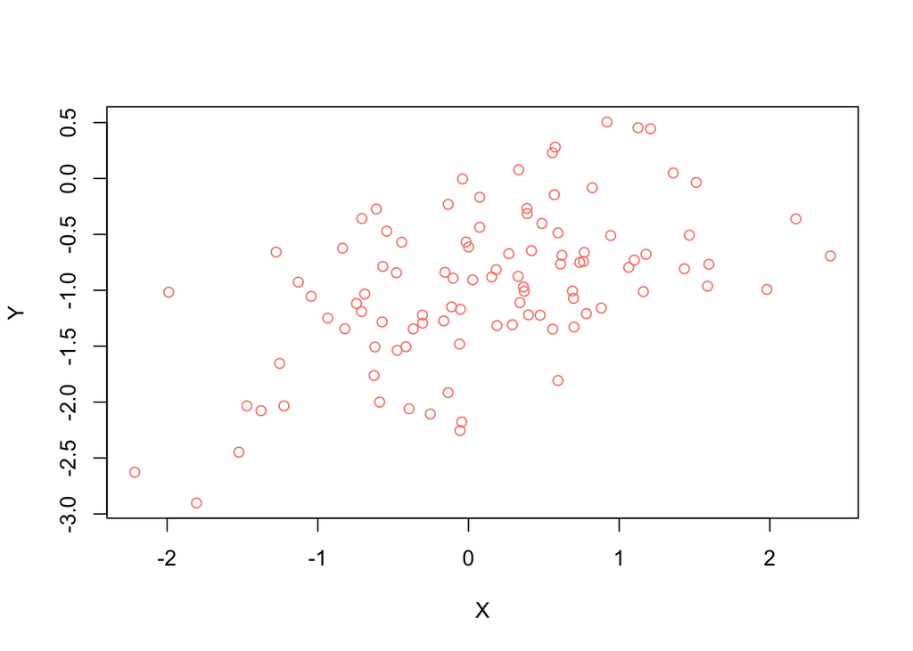

```r
plot(trainingData, col = "salmon", xlab = "X", ylab = "Y")
```

6. (4 pts.) Fit a least squares linear model to predict `y` using `x`. How do the estimated intercept and slope compare to the true values?

```r
# linear regression
summary(xy <- lm(y ~ x, data = trainingData))
```

```
Call:
lm(formula = y ~ x, data = trainingData)

Residuals:
     Min       1Q   Median       3Q      Max
-1.22689 -0.40393 -0.04575  0.41574  1.14118

Coefficients:
            Estimate Std. Error t value Pr(>|t|)
(Intercept) -1.00454    0.05804 -17.308  < 2e-16 ***
x            0.40072    0.06446   6.216 1.25e-08 ***
---
Signif. codes:  0 '***' 0.001 '**' 0.01 '*' 0.05 '.' 0.1 ' ' 1

Residual standard error: 0.5761 on 98 degrees of freedom
Multiple R-squared:  0.2828,    Adjusted R-squared:  0.2755
F-statistic: 38.64 on 1 and 98 DF,  p-value: 1.247e-08
```

7. (5 pts.) Compute the training MSE (using the training set) and test MSE (using the test data set). Is it reasonable to expect the training MSE to be smaller than the test MSE? Justify your response.

You would expect the training MSE, $0.325$ to be smaller than the test MSE, $0.265$ as that is what we are trying to minimize. However, given that the test data is an entire factor of ten larger than the training dataset, the training dataset isn’t large enough to be as robust as one might want, so the test MSE is smaller in this case.

```r
# predictions from the training data
xy_training_predict <- predict(xy )
mean((trainingData$y - xy_training_predict)^2) # training MSE
```

```
[1] 0.3252725
```

```r
# predictions from the testing data
xy_test_predict <- predict(xy, newdata = testData)
mean((testData$y - xy_test_predict)^2) # testing MSE
```

```
[1] 0.2652799
```

8. (3 pts.) Display the least squares line on the scatterplot obtained in (e). Draw the population regression line on the plot, in a different color. Use the `legend()` command to create an appropriate legend.

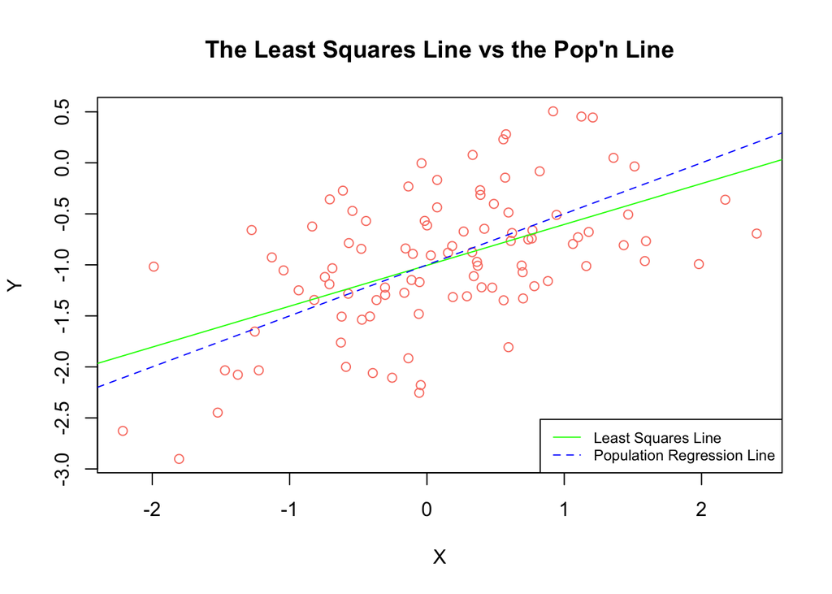

```r
plot(trainingData, main = "The Least Squares Line vs the Pop'n Line",
     col = "salmon", xlab = "X", ylab = "Y")
abline(xy, col = "green")
abline(a = -1, b = 0.5, col = "blue", lty = 2)

legend("bottomright",
       legend = c("Least Squares Line", "Population Regression Line"),
       col = c("green", "blue"),
       lty = c(1:2),
       cex = 0.75)
```

1. (7 pts.) Now fit a polynomial regression model that predicts `y` using `x` and the square of `x` (use `I(x^2)` in your code). Compute the training MSE (using the training set) and test MSE (using the test data set). Is it reasonable to expect the test MSE for the linear model to be smaller than the test MSE for the polynomial model? Justify your response.

The training MSE is $0.312$ and the test MSE is $0.282$

Yes, we would expect the test MSE for the linear model to be smaller than the test MSE for the polynomial model because the true relationship is linear. With the polynomial, we are adding unnecessary flexibility into the model at the cost of interpretability, which we don’t care about in this situation, and bias.

```r
# polynomial regression
summary(x2y <- lm(y ~ x + I(x^2), data = trainingData))
```

```
Call:
lm(formula = y ~ x + I(x^2), data = trainingData)

Residuals:
     Min       1Q   Median       3Q      Max
-1.30604 -0.38957 -0.06695  0.40921  1.13539

Coefficients:
            Estimate Std. Error t value Pr(>|t|)
(Intercept) -0.92420    0.06967 -13.265  < 2e-16 ***
x            0.41623    0.06394   6.509 3.33e-09 ***
I(x^2)      -0.10121    0.05020  -2.016   0.0465 *
---
Signif. codes:  0 '***' 0.001 '**' 0.01 '*' 0.05 '.' 0.1 ' ' 1

Residual standard error: 0.5673 on 97 degrees of freedom
Multiple R-squared:  0.3116,    Adjusted R-squared:  0.2974
F-statistic: 21.96 on 2 and 97 DF,  p-value: 1.362e-08
```

```r
# predictions from the training data
x2y_training_predict <- predict(x2y)
mean((trainingData$y - x2y_training_predict)^2) # training MSE
```

```
[1] 0.312189
```

```r
# predictions from the testing data
x2y_test_predict <- predict(x2y, newdata = testData)
mean((testData$y - x2y_test_predict)^2) # testing MSE
```

```
[1] 0.2819879
```

10. (8 pts.) Using the training data, fit KNN regressions of `y` on `x` for K = 1, 3, 5, and 10. Based on the test MSE, which value of K is optimal?

Based on the test MSE, having $K = 10$ is optimal as that has the minimum test MSE, $0.306$ of the four trials.

```r
# KNN for K = 1, 3, 5, and 10
knn_xy_k1 <- knnreg(y ~ x, k = 1, data = trainingData)
knn_xy_k3 <- knnreg(y ~ x, k = 3, data = trainingData)
knn_xy_k5 <- knnreg(y ~ x, k = 5, data = trainingData)
knn_xy_k10 <- knnreg(y ~ x, k = 10, data = trainingData)

# test predictions
knn_xy_k1_test <- predict(knn_xy_k1, newdata = testData)
knn_xy_k3_test <- predict(knn_xy_k3, newdata = testData)
knn_xy_k5_test <- predict(knn_xy_k5, newdata = testData)
knn_xy_k10_test <- predict(knn_xy_k10, newdata = testData)

# test MSEs
mean((testData$y - knn_xy_k1_test)^2)
```

```
[1] 0.5840194
```

```r
mean((testData$y - knn_xy_k3_test)^2)
```

```
[1] 0.3781989
```

```r
mean((testData$y - knn_xy_k5_test)^2)
```

```
[1] 0.3446176
```

```r
mean((testData$y - knn_xy_k10_test)^2)
```

```
[1] 0.3063052
```

11. (12 pts.) Using the `rnorm()` function repeatedly, create vectors `N1, N2, N3, N4, N5, N6, N7, N8, N9` and `N10`, each containing 1100 observations independently drawn from a N(0,1) distribution. Set the seed to 3 (`set.seed(3)`) prior to running the code to create all 10 vectors. These will serve as noise variables that are independent of the response, $Y$ (and therefore are not predictive of $Y$). Append the first 100 observations from each of these noise variables to your training set that already contains `x` and `y`. Also append the next 1000 observations from each of these noise variables to your test set that already contains `x` and `y`. Fit a linear regression model on the new training data set with `y` regressed on `x` and the 10 noise variables simultaneously. Compute the test MSE for the fitted model. Compare this test MSE to the test MSE from part (g). Then fit a KNN regression on the new training data set with `y` regressed on `x` and the 10 noise variables simultaneously using the optimal K from part (j). Compute the test MSE for the fitted model. Compare this test MSE to the test MSE from part (j).

```r
set.seed(3) # setting seed
# creating the noise vectors
N1 <- rnorm(1100, mean = 0, sd = 1)
N2 <- rnorm(1100, mean = 0, sd = 1)
N3 <- rnorm(1100, mean = 0, sd = 1)
N4 <- rnorm(1100, mean = 0, sd = 1)
N5 <- rnorm(1100, mean = 0, sd = 1)
N6 <- rnorm(1100, mean = 0, sd = 1)
N7 <- rnorm(1100, mean = 0, sd = 1)
N8 <- rnorm(1100, mean = 0, sd = 1)
N9 <- rnorm(1100, mean = 0, sd = 1)
N10 <- rnorm(1100, mean = 0, sd = 1)

# creating the new training dataset
newTrainingData <- cbind(trainingData, N1[1:100], N2[1:100], N3[1:100],
                      N4[1:100], N5[1:100], N6[1:100], N7[1:100],
                      N8[1:100], N9[1:100], N10[1:100])
colnames(newTrainingData) <- c("x", "y", "N1", "N2", "N3", "N4", "N5", "N6",
                               "N7", "N8", "N9", "N10")

# creating the new test dataset
newTestData <- cbind(testData, N1[101:1100], N2[101:1100], N3[101:1100],
                     N4[101:1100], N5[101:1100], N6[101:1100], N7[101:1100],
                     N8[101:1100], N9[101:1100], N10[101:1100])
colnames(newTestData) <- c("x", "y", "N1", "N2", "N3", "N4", "N5", "N6",
                               "N7", "N8", "N9", "N10")
```

The test MSE for the new fitted linear model is $0.302$, which is somewhat larger than the test MSE from part (g), $0.265$. It’s expected for the new test MSE to be larger than the original test MSE as the new noise variables add noise to the model, which then affects the test MSE.

```r
# the new lm
newXY <- lm(y ~ ., data = newTrainingData)

# predictions for the new testing data
newXY_test_predict <- predict(newXY, newdata = newTestData)
mean((newTestData$y - newXY_test_predict)^2) # testing MSE
```

```
[1] 0.3016816
```

The test MSE for the new KNN regression where $K = 10$ is $0.463$, which is larger than the test MSE from part (j), $0.306$. Similar to the fitted linear model, it is expected for the new test MSE for $K = 10$ to be larger than the original test MSE as the new noise variables add noise to the model, which then affects the test MSE.

```r
# KNN for K = 10
knn_newXY_k10 <- knnreg(y ~ ., k = 10, data = newTrainingData)
# test predictions
knn_newXY_k10_test <- predict(knn_newXY_k10, newdata = newTestData)
mean((newTestData$y - knn_newXY_k10_test)^2) # test MSE
```

```
[1] 0.4629107
```